# DATA471 Group Report

2023-09-02

# Authors: Group 15

```r
# TODO:
# Get table numbering correct
# Get student IDs
# Remove page limits from section titles
# Remove bullet point guidance from text body
```

# Background and Data [1-3 pages]

In our project, we are focusing on a time series dataset which is part of Statistics New Zealand’s COVID-19 data portal (1) - specifically we have picked the New Zealand Activity Index (NZAC). The NZAC was created in 2020 by the Treasury (2), but has since been extended to 2004 using historical data. This dataset is a monthly index that provides a summary of the eight constituent datasets which include data on: consumer spending, job vacancies, job-seeker numbers, electricity generation, and traffic data from both public and private institutions such as the Ministry of Social Development, ANZ and SEEK (2).

In this time series index, the eight component datasets are all also numerical. The NZAC is constructed using a weighted average of the components, and aims to show the common movements across the constituent datasets (2). The resultant values are then scaled so that it has the same mean and variance as year-on-year Real Gross Domestic Product growth (as the NZAC is intended as a proxy for the RGDP (2)). This style of activity index became common during the COVID-19 pandemic, when decision-makers in government and business were interested in higher frequency data than has previously been on offer. The NZAC is based on similar indices previously developed by the Chicago and New York Federal Reserves in the United States of America (2). In the United States of America, these measures provide weekly and monthly activity indices for the country (2). The New Zealand Treasury utilises the same weighted average method for the NZAC (2).

The NZAC is important as it is higher frequency than most economic datasets. Measures of GDP and the unemployment rate are released quarterly and can be revised for up to 2 years following release. It is well understood in the economics sector that accurate data can carry a 6-to-18-month lag, especially when considering the whole economy (2). These smaller indexes enable a faster release of data that is more up to date. The NZAC is a particularly useful dataset as it aims to reduce the noise that can be present in the component datasets, if used alone. The NZAC is highly correlated with Real GDP, which means that it could be helpful when making economic forecasts, or if you needed to know how the economy was performing before the quarterly GDP updates are released (2).

The NZAC dataset allows you to tell a clear economic story, especially when you look at how it corresponds to its component datasets and data from different economic sectors e.g., construction or tourism. There are clear features in the data which mark events such as the 2008 Global Financial Crisis and the impacts of the major COVID-19 lockdowns in New Zealand. This data may be of use in addressing questions about how economic activity has changed before, and after COVID. We may be able to look at which components have become more significant, or how the correlation to other datasets has changed.

There are no significant periods of missing date in the main index that we used, however some of the other data that we are using to assess the correlation of the NZAC does have some missing data (see the EDA section for more information). We performed joins on these datasets by using the date column as the join target (after some massaging for one dataset which we will detail in the EDA section).

# Ethics, Privacy and Security [1-2 pages]

### Ethics

The dataset is produced by the Treasury and published as part of the Statistics New Zealand COVID-19 data portal. This data is made available under the [Crown Copyright, Attribution 4.0 International (CC BY 4.0)](https://www.treasury.govt.nz/publications/nzac/nzac-qa-note) license which allows free use, adaptation and distribution of the data as long as the source is attributed, and a link to the license is provided (see earlier in the sentence).

This dataset is derived from constituent datasets that are also publicly available as either full datasets, or as data products. As far as we can tell, none of these datasets have licensing at all - although we believe it is reasonable to expect that Treasury has permission to utilise these datasets and publicly release their derivative product under their own license, which we will respect in using this data.

We also believe that this data was collected with informed consent (as it was mostly either measured values, or through a survey response) and we *assume* that this usage of the data falls within the original bounds of the consent. Here we need to trust that the Treasury has ensured this fact.

The primary dataset has clear ownership, licensing/terms of use, and transparency of where the data came from. As long as we adhere to the terms of the license, it seems difficult to identify any ethical issues in the use of this dataset.

### Privacy

This dataset is a series of monthly values which is a combination of multiple datasets. We note that some of the constituent datasets are derived from surveys which may have individual-level, identifying data (although we have not seen these datasets publicly available - these are more likely to be seen as data products). As the final, available data is tightly aggregated, we do not see any potential for de-anonymisation or risk of identifying data being released.

Based on the above, we do not believe there to be any obvious privacy issues with these datasets.

### Security

In uploading/updating the dataset on the appropriate website, the organisation needs to ensure that only the necessary people have the ability to access and modify these files. This is an access control mechanism to limit exposure as to who could potentially upload something malicious, or perhaps more likely, reuse a password and let in a blackhat who may choose to do the same.

We also need to be mindful here that the file itself is the correct one, and not some secret or embargoed data, and that it does not accidentally leak metadata (such as who worked on it, commentary from reviewers, exif data in case of images etc).

When the file has been uploaded, the database or server needs to be well defended to deter opportunistic (or targeted) attacks which may aim to change the file (malware, viruses etc - an integrity issue) or deny access to the file (DDOS - an availability issue). For this, we need a properly configured host, which can be a challenge for some (although hopefully not for either the Reserve Bank or Stats New Zealand).

When a user attempts to access/download the file, we must also ensure the integrity of the data from host to client. There are a few ways of doing this, but the most common would be by employing HTTPS in an attempt to thwart man-in-the-middle attacks. Additionally we might provide encryption, or a verification hash. A user might also elect to use a VPN or TOR-like browser, and a firewall and/or anti-virus.

In the specific case of this dataset, StatsNZ offers HTTPS by default, although no verification hash we are aware of. It is difficult to know the specifics of their defenses (which is a good thing). The data is provided in a .csv file, which is a fairly safe filetype given it is pure text data (instead of something like a .pdf or office documents which can utilise macros).

We do not observe any particular security issues related to this dataset.

For our project, the main source of security issues would be in the communication and sharing of files between group members. We have set up a Github repository in order to do this sharing. The repository mitigates many of these potential issues that we might otherwise have in sharing files by email or discord. The repository also features strict access controls in the form of a white-list, and Github itself requires authentication to access (usually in the form of a ssh key or personal access token) which disallows contributions from bad actors (excluding anyone working a Github/Microsoft that is). Although, if one was conniving enough, the information contained in the Github repository may allow someone to do some social engineering, although the attacker would likely have to put in a lot of effort into a (very) low value target.

We do not have any specific counter-measures related to our project outside of good internet hygiene (don’t go visiting dodgy sites, or clicking on emails from Nigerian royalty), use a firewall and/or anti-virus, knowing who your group members are, and limiting physical access to your devices.

# Exploratory Data Analysis [3-6 pages]

### Data and Preparation

- Select the relevant columns for each indicator
- Convert the date columns to the ‘date’ date type
- Ensure all of the dates are the same frequency and date (or massage them to such a state):
  - The ANZ Activity Outlook had date values for the end of each month - we converted these to the first date of the next month for consistency with the rest of the datasets.
  - All datasets have a monthly frequency and all other datasets were dated at the start of the month.

The duration of these datasets are as seen in Table 1 below:

Dataset durations

| Dataset | Start.Date | End.Date |
| --- | --- | --- |
| NZAC | October 2003 | June 2023 |
| ANZ Activity Outlook | April 2008 | July 2023 |
| BusinessNZ Performance Manufacturing Index | August 2002 | June 2023 |
| SEEK Job Ad Index | January 2002 | June 2023 |
| SEEK Applications per Ad Index | Febuary 2008 | June 2023 |

### Summary Statistics

Here we show the summary statistics of the resultant dataset after preparation and merging.

Summary statistics

| Dataset | Variable | Minimum | Median | Mean | Maximum | Missing |
| --- | --- | --- | --- | --- | --- | --- |
| All | DATE | 2003-10-01 | - | - | 2023-06-01 | 0 |
| NZAC | NZAC | -13.605 | 2.797 | 2.772 | 33.801 | 22 |
| ANZ | ACT_OUTLOOK | -55.10 | 22.25 | 18.85 | 58.50 | 89 |
| PMI | PMI | 26.03 | 53.35 | 53.00 | 64.21 | 8 |
| PMI | PRODUCTION | 19.29 | 53.92 | 53.52 | 68.09 | 8 |
| PMI | EMPLOYMENT | 38.77 | 50.95 | 50.55 | 57.43 | 8 |
| PMI | NEW_ORDERS | 18.25 | 55.61 | 54.77 | 70.48 | 8 |
| PMI | FINISHED_STOCKS | 36.23 | 51.78 | 51.77 | 60.21 | 8 |
| PMI | DELIVERIES | 22.91 | 53.43 | 52.69 | 63.69 | 8 |
| SEEK Jobs | ADS_SA_INDEX | 29.57 | 113.93 | 115.89 | 211.49 | 1 |
| SEEK Ads | CA_SA_INDEX | 0.0 | 107.7 | 117.1 | 284.7 | 75 |

## Visualisation

Now onto the visualisations. Below we’ve divided this section into parts:

- Variable correlations
- NZAC vs most correlated plot
- SEEK Ads vs Applications
- NZAC decomposition

We start with the variable correlations - this work was done first (after summary statistics etc) to inform further plots. Our objective is to identify which variables best correlate to our response, NZAC value, and to see whether there may be concerns of multicollinearity to be cognisant of in future modelling stages.

### Correlation

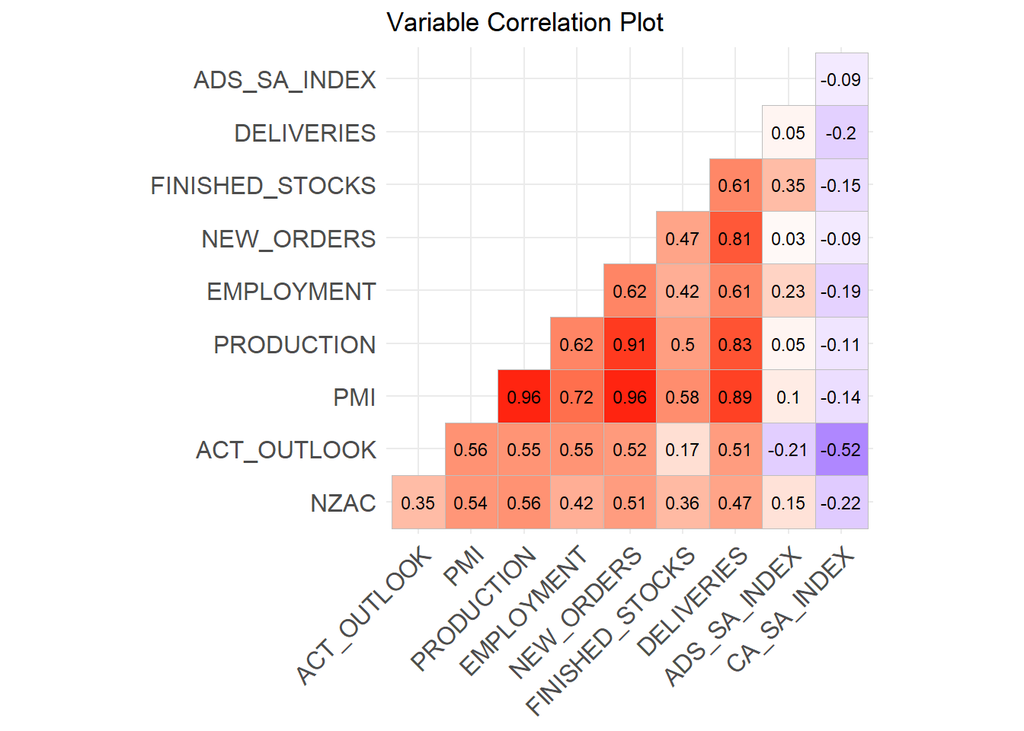

Correlation Plot

First, the reader may want to note that the correlations above were made only on cases which had pairwise complete observations between the specific variables as we did have some missing values. We expect that ACT_OUTLOOK and CA_SA_INDEX may not be as accurate as the other variables as they had significantly more missing values. We use the default pearson correlation coefficient here.

The plot itself shows some interesting results:

- The NZAC is moderately correlated to most of the predictors seen here, with correlations between 0.4-0.5 being common.
- CA_SA_INDEX is particularly interesting, as it appears to correlate more to a slower economy (the opposite from the other measures) as being a measure of job applications per job advertisement. This makes sense.
- Consequently, the NZAC has a weak negative correlation with CA_SA_INDEX at -0.22.
- PRODUCTION best correlates to the NZAC at 0.56, while ADS_SA_INDEX correlated the least at 0.15.
- Additionally, we observe the potential for multicollinearity between PMI, PRODUCTION, NEW_ORDERS and potentially DELIVERIES. This is unsurprising given that these measures were all from the same dataset, and all aim to measure similar things, i.e., all new orders to manufacturers will need to be produced, and subsequently delivered.

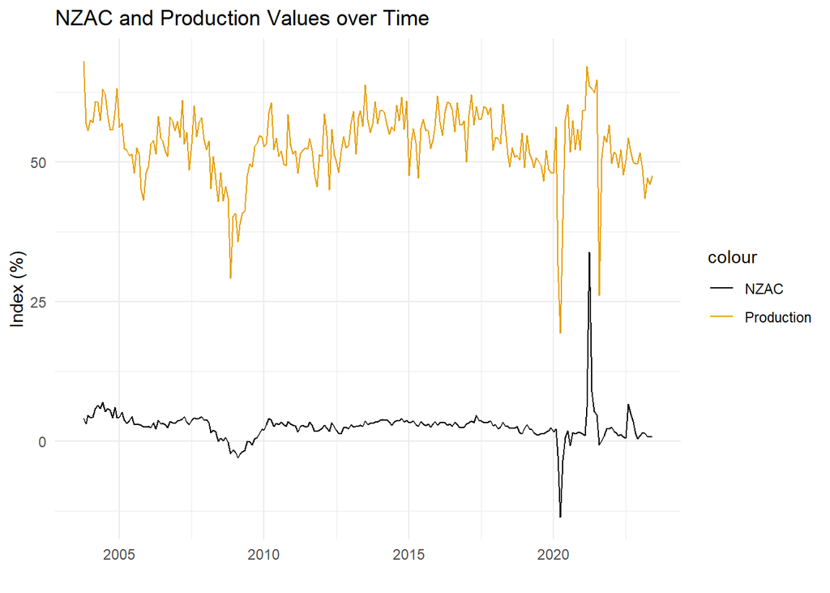

NZAC and Production Values

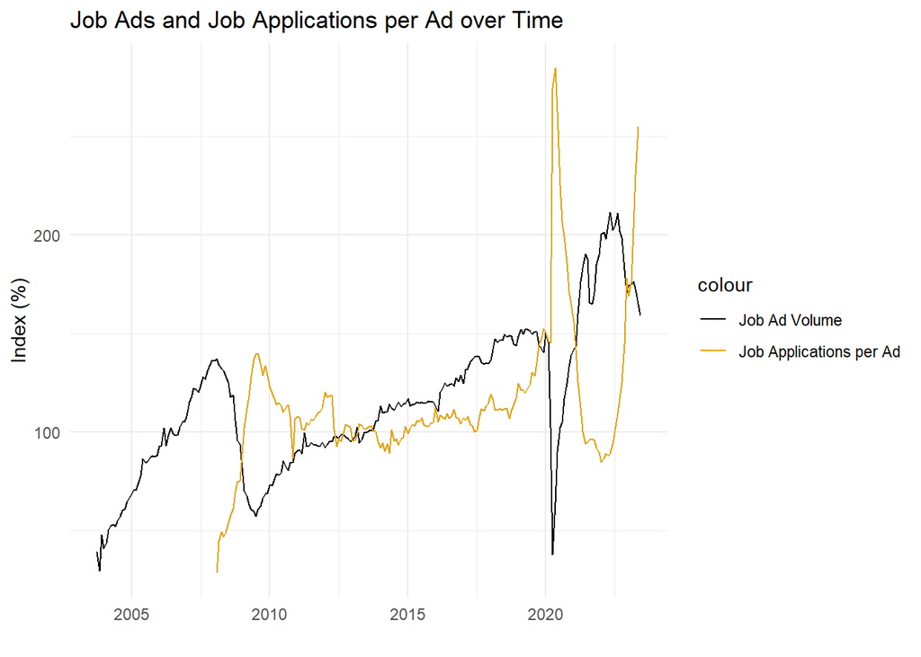

SEEK Jobs data: Job Ads and Job Applications

In the job group, job applications per ads volumes index is derived from the other index (ads volumes index). This explains the contrast patterns between them. During recession 2008 and pandemic 2020, the ads volumes index decreased dramatically, where as the job applications per ads volumes index increased accordingly. Likewise, post-pandemic period recorded the opposite trend of these two indexes the other way around.

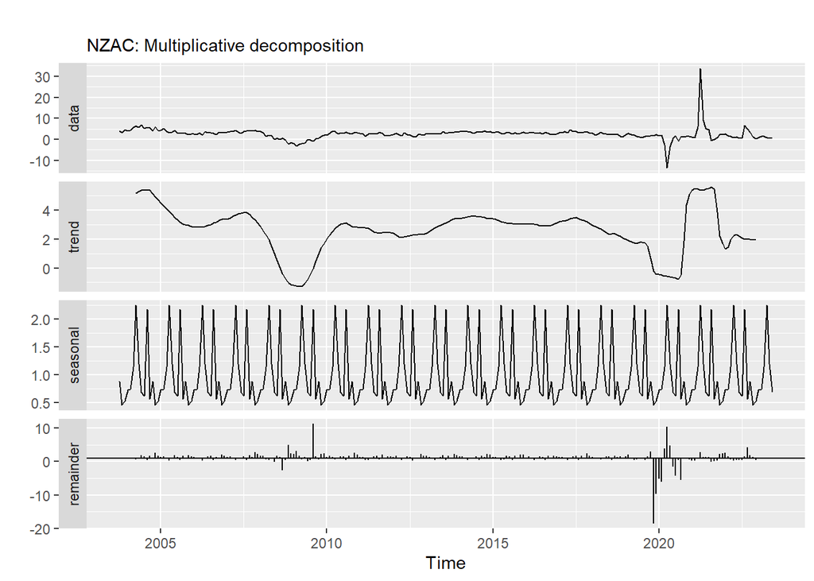

Temporal decomposition plot

The seasonal patterns shows two hikes every year.

# Overall Report

# References

1.

COVID-19 data portal [Internet]. Statistics New Zealand; 2020 [cited 2023 Sep 2]. Available from: https://www.stats.govt.nz/experimental/covid-19-data-portal

2.

New zealand activity index (NZAC): Technical note [Internet]. The Treasury; 2020 [cited 2023 Sep 2]. Available from: https://www.treasury.govt.nz/publications/nzac/nzac-technical-note